# Meeting a Mate in Four Minutes

This project aims to draw conclusions from speed dating data collected at Columbia University and build a model to predict whether two participants will match.

The dataset, sourced from Kaggle, comes as a single table. I designed and created an SQLite database to segment the data into a more useful and malleable structure. Using this database I explored the difference in correlatation with participants’ decisions to pursue a second date, whether placing limitations on how many match decisions were allowed affected males and females differently, how a participants number of matches vary with self-rated attractiveness and partner rated attractiveness and how 'yes' decisions trend with the sequential order of a date throughout the event.

## Evaluating a Logistic Regression model against the baseline

After creating the database I implemented a logistic regression model to pedict a participants' decision. To test my model I first built a baseline model which randomly guessed whether a participant's partner would give a 'yes' decision. Random guessing produces an accuracy 50%.

```python
random_match_predictions = []
for i in range(len(speed_data)):
    random_match_predictions.append(randint(0,1))

print("Random Guess Accuracy: " + str(accuracy_score(speed_data['match'],random_match_predictions)))
```

```
Random Guess Accuracy: 0.495464311291
```

It turns out that the decision made by a participant's partner could be predicted well above the baseline with just a single feature - how attractive the partner rated the participant. Adding other features to this model only marginally increased performance, and in some cases detracted from the model's accuracy. This simple logistic regression predicts matches with roughly 83% accuracy.

Since there was so much predictive power in the attractiveness attribute I performed further analysis based on the attractiveness attribute within the dataset. Those results will be discussed later on.

```python
lr_data = speed_data.dropna(axis=0,subset=['attr_o'])
features = ['attr_o']
model = LogisticRegression()
X_train, X_test, y_train, y_test = train_test_split(lr_data[features], lr_data['match'],test_size = 0.3)
model.fit(X_train,y_train)
model.score(X_test,y_test)
```

```
0.83224489795918366
```

## Does the order of when you meet your partner of a have an impact on their decision?

Before diving into a deep analysis of what influences participants, I wanted to establish whether simply the order of a date during the event had an influence on their 'yes' decisions.

Related research on sequential decision-making from the University of Negev in Isreal shows that when judges are presiding in court they are far more lenient at the beginning of the day, and likewise after taking a break. The study observed 8 parole judges and included over 1000 rulings over the course of 50 Days.

"They found that at the beginning of a court session about 65 percent of the rulings tended to be in favour of the prisoner, but the chance of a favourable ruling declined to near zero by the end of the session" - theglobeandmail.com

I suspected speed-dating participants might exhibit similar behavior, so I graphed their decisions over the course of the event.

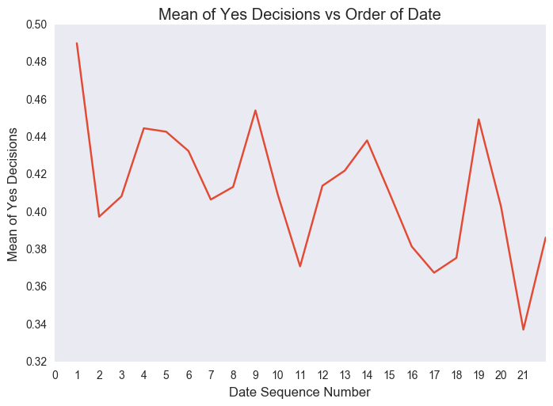

```python
aggregated_order = pd.pivot_table(speed_data,values='dec_o',columns='order',aggfunc='mean')
#aggregated_order.to_csv('order_of_date_data.csv')
sns.set_style('dark',{'axes.grid' : False})
aggregated_order.plot()
plt.xticks(range(len(aggregated_order)))
plt.title('Mean of Yes Decisions vs Order of Date')
plt.ylabel('Mean of Yes Decisions')
plt.xlabel('Date Sequence Number')
plt.show()
```

The advandage of being someone's first date is apparent from this graph, however it is diffcult to conclude what effect the mid-event break is having, if any. To explore this further I separarted dates into several buckets based on their order: first/last, immediately before the break, and immediately after the break.

Speed dating behavior turned out to be a bit different compared to parole rulings. As seen below it seems that a date immediately before the break is slighty more advantagous than immediately after. The advantage to being someone's first or last date is also confirmed.

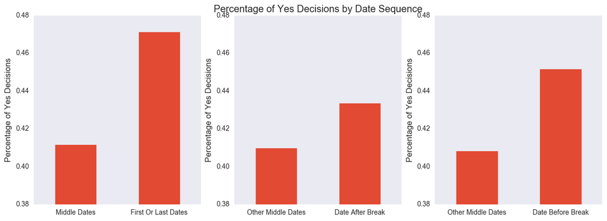

```python
plt.figure(1,figsize=(15,5))

plt.subplot(131)
first_or_last_pivot.plot(kind='bar')
plt.ylim([0.38,0.48])
plt.xlabel("")
plt.ylabel("Percentage of Yes Decisions")
labels = ['Middle Dates','First Or Last Dates']
plt.xticks(range(2), labels, rotation='horizontal')

plt.subplot(132)
after_break_vs_other_mid_pivot.plot(kind='bar')
plt.ylim([0.38,0.48])
plt.title("Percentage of Yes Decisions by Date Sequence")
plt.xlabel("")
plt.ylabel("Percentage of Yes Decisions")
labels = ['Other Middle Dates','Date After Break']
plt.xticks(range(2), labels, rotation='horizontal')

plt.subplot(133)
plt.ylim([0.38,0.48])
before_break_vs_other_mid_pivot.plot(kind='bar')
plt.xlabel("")
plt.ylabel("Percentage of Yes Decisions")
labels = ['Other Middle Dates','Date Before Break']
plt.xticks(range(2), labels, rotation='horizontal')
plt.show()
```

## Observed differences in attribute importance under limitations

*See Appendix A for dataframe construction and manipulation

During the speed dating study there were two scenarios a speed-date event could fall under. In scenario 1 participants were able to give a 'yes' decision to as many dates as they wanted. In scenario 2 participants were limited to only giving a 'yes' response to only half of their partners.

I wanted to determine how a participant's attribute ratings would vary with their decision on a partner when there were constraints placed on their 'yes' responses.

I looked at how well the ratings of attractiveness, intelligence and fun correlated with a participant's decision for both scenarios and also segmented the results by gender. The result was rather striking.

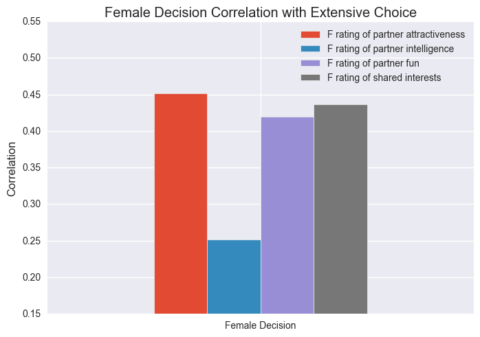

|  | F rating of partner attractiveness | F rating of partner intelligence | F rating of partner fun | F rating of shared interests |
| --- | --- | --- | --- | --- |
| Female Decision | 0.451068 | 0.251687 | 0.419556 | 0.436017 |

[figure not shown]

|  | F rating of partner attractiveness | F rating of partner intelligence | F rating of partner fun | F rating of shared interests |
| --- | --- | --- | --- | --- |
| Female Decision | 0.413603 | 0.200846 | 0.44293 | 0.421298 |

```python
sns.set_style('dark',{'axes.grid' : True})
extensive_female_dec_corrmat.head(1).iloc[:,1:].plot(kind='bar',rot=0)
extensive_female_dec_corrmat.head(1).iloc[:,1:].to_csv('extended female decision corrmat.csv')

plt.ylabel('Correlation')
plt.title('Female Decision Correlation with Extensive Choice')
plt.ylim([0.15,0.55])
plt.show()
display(extensive_female_dec_corrmat.head(1).iloc[:,1:])
limited_female_dec_corrmat.head(1).iloc[:,1:].plot(kind='bar',rot=0)
limited_female_dec_corrmat.head(1).iloc[:,1:].to_csv('limited female decision corrmat.csv')
plt.ylabel('Correlation')
plt.title('Female Decision Correlation with Limited Choice')
plt.ylim([0.15,0.5])
plt.show()
display(limited_female_dec_corrmat.head(1).iloc[:,1:])
```

## Men's Inverse Reaction to Limitation

The unexpected finding here was that men exhibited the exact opposite behavior when limiting their number of 'yes' decisions. As their options became limited, they were more responsive to partners they percieved to be more attractive, intelligent and fun. The greatest disparity in attribute correlation between limited and extensive choice is the jump in how men's rating of how fun they perceive their partner affected their 'yes' decisions.

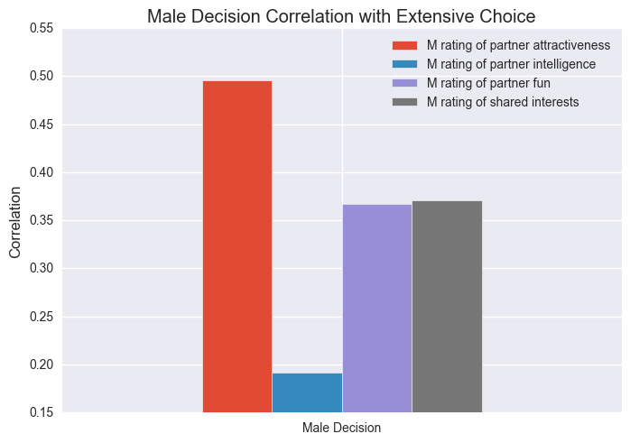

|  | M rating of partner attractiveness | M rating of partner intelligence | M rating of partner fun | M rating of shared interests |
| --- | --- | --- | --- | --- |
| Male Decision | 0.495178 | 0.191948 | 0.366644 | 0.370566 |

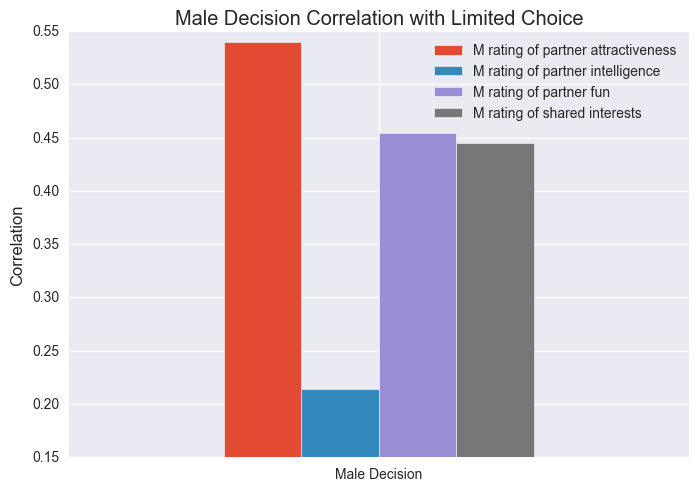

|  | M rating of partner attractiveness | M rating of partner intelligence | M rating of partner fun | M rating of shared interests |
| --- | --- | --- | --- | --- |
| Male Decision | 0.539649 | 0.213982 | 0.454562 | 0.444853 |

```python
sns.set_style('dark',{'axes.grid' : True})

extensive_male_dec_corrmat.head(1).iloc[:,1:].plot(kind='bar',rot=0)
extensive_male_dec_corrmat.head(1).iloc[:,1:].to_csv('extended male decision corrmat.csv')
plt.ylabel('Correlation')
plt.title('Male Decision Correlation with Extensive Choice')
plt.ylim([0.15,0.55])
plt.show()
display(extensive_male_dec_corrmat.head(1).iloc[:,1:])
limited_male_dec_corrmat.head(1).iloc[:,1:].plot(kind='bar',rot=0)
limited_male_dec_corrmat.head(1).iloc[:,1:].to_csv('limied male decision corrmat.csv')
plt.ylabel('Correlation')
plt.title('Male Decision Correlation with Limited Choice')
plt.ylim([0.15,0.55])
plt.show()
display(limited_male_dec_corrmat.head(1).iloc[:,1:])
```

## Observed differences in match results based on self-rated attractiveness

Since attractiveness seemed to be a rather accuate predictor of whether participants give a 'yes' decision, I wanted to explore the relationship between people's rating of their own attractiveness and the matches they receive.

I grouped participants using KMeans clustering based on how highly they rated their own attractiveness the night of the event. I performed the classification using both 5 and 8 clusters, with similar findings.

On the aggregate those who rate themselves extremely high do in fact receive more matches than those who rate themselves extremely low in attractiveness, but not by much. This begged a follow-up question, though. Do results for high self-rated attractive males differ from the same group of females? This breakdown revealed a dramatic separation.

```python
self_rated_five_class_pivot
#Gender 0 represents females, 1 represents males
```

| gender self_rated_class | 0 | 0 1 | 0 2 | 0 3 | 0 4 | 1 0 | 1 | 1 2 | 1 3 | 1 4 |
| --- | --- | --- | --- | --- | --- | --- | --- | --- | --- | --- |
| number of matches | 2.972117 | 2.410468 | 2.223684 | 2.501487 | 2.892996 | 2.985677 | 3.803625 | 2.018100 | 2.793905 | 2.026582 |
| self-rated attractiveness at sign-up | 5.709759 | 9.179063 | 3.401316 | 7.000000 | 8.000000 | 5.623698 | 9.413897 | 3.574661 | 7.000000 | 8.000000 |

## Observed differences in match results based on partner-rated attractiveness

The above results were rather striking, so I wanted to see if they would be repeated when grouping participants based on how their partners rated their attractiveness. This time the clustering was performed based on the average attractiveness rating a participant received from their partners, not themselves. The outcome supported the results of the earlier logistic regression.

Using the parner's rating as the clustering feature participants, for both genders, who were rated as more attractive literally outmatch their peers, and in order nonetheless. The disparity between number of matches, however, is far greater between highest vs lowest rated males than it is for the same groups in females

```python
partner_rated_five_class_pivot
#Gender 0 represents females, 1 represents males
```

| gender partner_rated_class | 0 | 0 1 | 0 2 | 0 3 | 0 4 | 1 0 | 1 | 1 2 | 1 3 | 1 4 |
| --- | --- | --- | --- | --- | --- | --- | --- | --- | --- | --- |
| number of matches | 2.209770 | 1.365957 | 3.501220 | 1.727592 | 3.824666 | 3.127660 | 0.915563 | 3.434985 | 2.190972 | 4.877888 |
| avg_attractiveness_rating | 6.156153 | 4.140736 | 7.035599 | 5.227267 | 7.886355 | 6.164608 | 4.117198 | 7.027031 | 5.230206 | 7.903055 |

## Building a Better Model

After exploring the ins and outs of how attractiveness impacts out participants the next goal was to build a model that takes all attribute ratings into account to predict the outcome of the speed date.

For this a Random Forest classifier was used, and to find the optimal parameters I performed a gridsearch on the model.

```python
rfc = RandomForestClassifier()
features = ['condtn', 'Male Age', 'round','Female Age','F rating of partner attractiveness','M rating of partner attractiveness', 'F rating of partner fun','M rating of partner fun', 'F rating of partner intelligence','M rating of partner intelligence', 'F rating of partner sincerity','M rating of partner sincerity', 'F rating of partner shared interests','M rating of partner shared interests', 'F rating of partner ambition','M rating of partner ambition', 'order','age_difference']
X = dates[features]
y = dates['match']
param_grid = {
    'n_estimators': [50, 100,200,500],#, 200, 500],
    'max_features': ['auto', 'sqrt', 'log2'],
    'max_depth': [10,20,100,None]
}
CV_rfc = GridSearchCV(estimator=rfc, param_grid=param_grid, cv= 5)
CV_rfc.fit(X, y)
print(CV_rfc.best_params_)
print(CV_rfc.best_score_)
```

```
{'n_estimators': 50, 'max_depth': 20, 'max_features': 'sqrt'}
0.85175983436853
```

The Random Forest model taking into account all attributes and a few other features about the date scored nearly 85.1%. A marginal gain over the Logistic Regression at a significant cost increase in computing power and analyst effort.

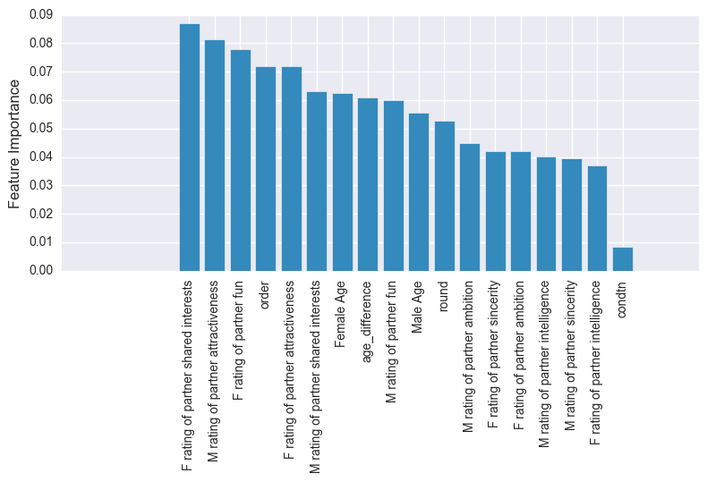

```python
feature_importance_dictionary = {}
for index, i in enumerate(features):
    feature_importance_dictionary[i] = CV_rfc.best_estimator_.feature_importances_[index]

feature_importance_dictionary
x =sorted(feature_importance_dictionary.items(), key=lambda x: x[1],reverse=True)
#print(x)

feature_importance_list = []
feature_importance_labels = []
for i in x:
    feature_importance_list.append(i[1])
    feature_importance_labels.append(i[0])

plt.bar(range(len(feature_importance_list)), feature_importance_list, align='center')
plt.xticks(range(len(feature_importance_labels)), feature_importance_labels,rotation=90)
plt.ylabel('Feature Importance')
plt.tight_layout()
plt.show()
```

After seeing what features were most important in a match, I was curious what factors impact the decisions of male vs. female participants. Again using a Random Forest, we find that men are most swayed by how attractive they perceive their partner, while females are a bit more balanced between how attractive and fun they rate their partners as well as how they rate their shared interests. As with predicting matches, we find that the accuracy for predicting decisions does not significantly improve over the Logistic Regression.

```
{'n_estimators': 500, 'max_features': 'auto', 'max_depth': 10}
0.7358178053830228
```

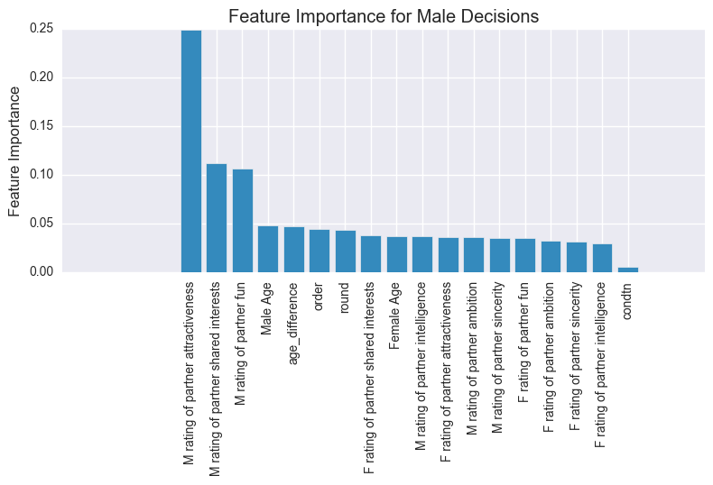

```python
rfc = RandomForestClassifier()
features = ['condtn', 'Male Age', 'round','Female Age','F rating of partner attractiveness','M rating of partner attractiveness', 'F rating of partner fun','M rating of partner fun', 'F rating of partner intelligence','M rating of partner intelligence', 'F rating of partner sincerity','M rating of partner sincerity', 'F rating of partner shared interests','M rating of partner shared interests', 'F rating of partner ambition','M rating of partner ambition', 'order','age_difference']
X = dates[features]
y = dates['Male Decision']
param_grid = {
    'n_estimators': [50, 100,200,500],
    'max_features': ['auto', 'sqrt', 'log2'],
    'max_depth': [10,20,100,None]
}
CV_rfc = GridSearchCV(estimator=rfc, param_grid=param_grid, cv= 5)
CV_rfc.fit(X, y)
print(CV_rfc.best_params_)
print(CV_rfc.best_score_)

feature_importance_dictionary = {}
for index, i in enumerate(features):
    feature_importance_dictionary[i] = CV_rfc.best_estimator_.feature_importances_[index]

feature_importance_dictionary
x =sorted(feature_importance_dictionary.items(), key=lambda x: x[1],reverse=True)
#print(x)

feature_importance_list = []
feature_importance_labels = []
for i in x:
    feature_importance_list.append(i[1])
    feature_importance_labels.append(i[0])

plt.bar(range(len(feature_importance_list)), feature_importance_list, align='center')
plt.xticks(range(len(feature_importance_labels)), feature_importance_labels,rotation=90)
plt.title("Feature Importance for Male Decisions")
plt.ylabel('Feature Importance')
plt.tight_layout()
plt.show()
```

```
{'n_estimators': 100, 'max_features': 'sqrt', 'max_depth': 10}
0.7333333333333333
```

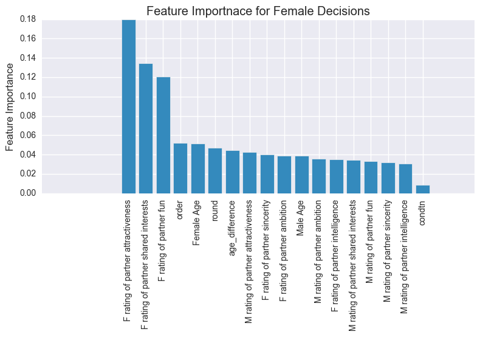

```python
rfc = RandomForestClassifier()
features = ['condtn', 'Male Age', 'round','Female Age','F rating of partner attractiveness','M rating of partner attractiveness', 'F rating of partner fun','M rating of partner fun', 'F rating of partner intelligence','M rating of partner intelligence', 'F rating of partner sincerity','M rating of partner sincerity', 'F rating of partner shared interests','M rating of partner shared interests', 'F rating of partner ambition','M rating of partner ambition', 'order','age_difference']
X = dates[features]
y = dates['Female Decision']
param_grid = {
    'n_estimators': [50, 100,200,500],
    'max_features': ['auto', 'sqrt', 'log2'],
    'max_depth': [10,20,100,None]
}
CV_rfc = GridSearchCV(estimator=rfc, param_grid=param_grid, cv= 5)
CV_rfc.fit(X, y)
print(CV_rfc.best_params_)
print(CV_rfc.best_score_)

feature_importance_dictionary = {}
for index, i in enumerate(features):
    feature_importance_dictionary[i] = CV_rfc.best_estimator_.feature_importances_[index]

feature_importance_dictionary
x =sorted(feature_importance_dictionary.items(), key=lambda x: x[1],reverse=True)
#print(x)

feature_importance_list = []
feature_importance_labels = []
for i in x:
    feature_importance_list.append(i[1])
    feature_importance_labels.append(i[0])

plt.bar(range(len(feature_importance_list)), feature_importance_list, align='center')
plt.xticks(range(len(feature_importance_labels)), feature_importance_labels,rotation=90)
plt.ylabel('Feature Importance')
plt.tight_layout()
plt.title('Feature Importnace for Female Decisions')
plt.show()
```

## Conclusions

In conclusion, it's neither surprising nor uplifting that the outcome of a four minute date hinges largely on how attractive both parties perceive the other to be. While other factors can weigh in, they hardly affect a person's decision to pursue a second date.

However, this study suggests some interesting findings. Frist is that when going through a sequence of dates, it is far more likely that you match with those you meet early on. Another is that decision factors vary when choices are restricted. As a male limitations tend work in your favor if your counterparty doesn't find you all that attractive or fun because the bar has been lowered. As a speed-dating female, however, you might find that having more competition actually works in your favor!

It's been said many times that we're terrible judges of ourselves, and that sentiment is echoed in the world of speed-dating. Given that performance in speed dating is based on matching, men seem to self-rank somewhat well where women do an abysmal job of it.

## Appendix A

```python
conn = sqlite3.connect('SpeedDatingDB.sqlite')

dates = pd.read_sql_query\
("""
SELECT m.date_id
      ,m.iid as 'Male IID'
      ,m.pid as 'Female IID'
      ,m.wave
      ,m.condtn
      ,m.round
      ,m.age as 'Male Age'
      ,f.age as 'Female Age'

      ,m.dec_o as 'Female Decision'
      ,f.dec_o as 'Male Decision'

      ,m.attr_o as 'F rating of partner attractiveness'
      ,f.attr_o as 'M rating of partner attractiveness'

      ,m.fun_o as 'F rating of partner fun'
      ,f.fun_o as 'M rating of partner fun'

      ,m.intel_o as 'F rating of partner intelligence'
      ,f.intel_o as 'M rating of partner intelligence'

      ,m.sinc_o as 'F rating of partner sincerity'
      ,f.sinc_o as 'M rating of partner sincerity'

      ,m.shar_o as 'F rating of partner shared interests'
      ,f.shar_o as 'M rating of partner shared interests'

      ,m.amb_o as 'F rating of partner ambition'
      ,f.amb_o as 'M rating of partner ambition'

      ,m.shar_o as 'F rating of shared interests'
      ,f.shar_o as 'M rating of shared interests'

      ,m.match
      ,m.[order]

      from male_side_of_dates m
      join female_side_of_dates f on f.date_id = m.date_id


""", conn)
dates['age_difference'] = dates['Male Age'] - dates['Female Age']
dates = dates.dropna()
```

```python
limited_dates = dates[dates['condtn']==1]
extensive_dates = dates[dates['condtn']==2]
limited_female_dec_corrmat = limited_dates[['Female Decision','F rating of partner attractiveness', 'F rating of partner intelligence', 'F rating of partner fun', 'F rating of shared interests']].corr()
extensive_female_dec_corrmat = extensive_dates[['Female Decision','F rating of partner attractiveness', 'F rating of partner intelligence', 'F rating of partner fun', 'F rating of shared interests']].corr()
limited_male_dec_corrmat = limited_dates[['Male Decision','M rating of partner attractiveness','M rating of partner intelligence', 'M rating of partner fun', 'M rating of shared interests']].corr()
extensive_male_dec_corrmat = extensive_dates[['Male Decision','M rating of partner attractiveness','M rating of partner intelligence', 'M rating of partner fun','M rating of shared interests']].corr()
```

## Appendix B

```python
query = """SELECT p.iid
        , go.go_out_description [goes_out_desc]
        , fd.go_out_description [freq_date_desc]
        , r.avg_attractiveness_rating
        , r.avg_fun_rating
        , r.avg_intelligence_rating
        , r.avg_ambition_rating
        , p.[number of matches]
        , sra.[self-rated attractiveness at sign-up]
        , sra.[self-rated intelligence at sign-up]
        , p.gender

    from participants p
    left join ratings r on p.iid = r.iid
    left join Go_Out_and_Frequency_of_Dates_Description go on go.go_out_id = p.go_out
    left join Go_Out_and_Frequency_of_Dates_Description fd on fd.go_out_id = p.frequency_of_dates
    left join self_rated_attributes sra on sra.iid = p.iid
    order by p.iid"""

partic_and_ratings = pd.read_sql_query(query,conn)
```

```python
features = ['avg_attractiveness_rating']
partner_rated_five_way_classifier = KMeans(5)
partic_and_ratings = partic_and_ratings.dropna()
X = partic_and_ratings[features]
X2 = X # pd.get_dummies(X,columns=['goes_out_desc','freq_date_desc']).dropna()
partic_and_ratings['partner_rated_class'] = partner_rated_five_way_classifier.fit_predict(X)


features = ['self-rated attractiveness at sign-up']
five_way_classifier = KMeans(5)
partic_and_ratings = partic_and_ratings.dropna()
X = partic_and_ratings[features]
partic_and_ratings['self_rated_class'] = five_way_classifier.fit_predict(X)
partic_and_ratings
```

[output not shown]

6698 rows × 13 columns

```python
self_rated_five_class_pivot = pd.pivot_table(partic_and_ratings,index='gender',columns=['self_rated_class'],values=['number of matches','self-rated attractiveness at sign-up'],aggfunc='mean')
self_rated_five_class_pivot = self_rated_five_class_pivot.unstack()
self_rated_five_class_pivot = self_rated_five_class_pivot.unstack()
self_rated_five_class_pivot = self_rated_five_class_pivot.unstack()
self_rated_five_class_pivot
```

| gender self_rated_class | 0 | 0 1 | 0 2 | 0 3 | 0 4 | 1 0 | 1 | 1 2 | 1 3 | 1 4 |
| --- | --- | --- | --- | --- | --- | --- | --- | --- | --- | --- |
| number of matches | 2.972117 | 2.410468 | 2.223684 | 2.501487 | 2.892996 | 2.985677 | 3.803625 | 2.018100 | 2.793905 | 2.026582 |
| self-rated attractiveness at sign-up | 5.709759 | 9.179063 | 3.401316 | 7.000000 | 8.000000 | 5.623698 | 9.413897 | 3.574661 | 7.000000 | 8.000000 |

```python
partner_rated_five_class_pivot = pd.pivot_table(partic_and_ratings,index='gender',columns=['partner_rated_class'],values=['number of matches','avg_attractiveness_rating'],aggfunc='mean',)
partner_rated_five_class_pivot = partner_rated_five_class_pivot.unstack()
partner_rated_five_class_pivot = partner_rated_five_class_pivot.unstack()
partner_rated_five_class_pivot = partner_rated_five_class_pivot.unstack()
partner_rated_five_class_pivot
```

| gender partner_rated_class | 0 | 0 1 | 0 2 | 0 3 | 0 4 | 1 0 | 1 | 1 2 | 1 3 | 1 4 |
| --- | --- | --- | --- | --- | --- | --- | --- | --- | --- | --- |
| number of matches | 2.209770 | 1.365957 | 3.501220 | 1.727592 | 3.824666 | 3.127660 | 0.915563 | 3.434985 | 2.190972 | 4.877888 |
| avg_attractiveness_rating | 6.156153 | 4.140736 | 7.035599 | 5.227267 | 7.886355 | 6.164608 | 4.117198 | 7.027031 | 5.230206 | 7.903055 |

## Appendix C

```python
import sqlite3
import matplotlib.pyplot as plt
import pandas as pd
from sklearn.metrics import accuracy_score
from random import randint
from sklearn.linear_model import LogisticRegression
from sklearn.model_selection import train_test_split
from sklearn.grid_search import GridSearchCV
from sklearn.ensemble import RandomForestClassifier
import seaborn as sns
from sklearn.cluster import KMeans
import matplotlib
from IPython.display import display
matplotlib.style.use('ggplot')
```

```python
speed_data = pd.read_csv('./Speed Dating Data2.csv', encoding = 'iso-8859-1')
speed_data.shape
```

```
(8378, 195)
```

```python
order_graph_dates['round'].value_counts()
```

```
18    403
22    346
21    338
20    234
19    206
Name: round, dtype: int64
```

```python
order_graph_dates = dates[dates['round']<28]
order_graph_dates = order_graph_dates[order_graph_dates['round']> 15]
order_graph_dates['yes_dec_total'] = order_graph_dates['Male Decision'] + order_graph_dates['Female Decision']
```

```python
def date_before_break(date_order):
    if (date_order == -1 or date_order == -0.5):
        return(1)
    else:
        return(0)
```

```python
def date_after_break(date_order):
    if (date_order == 1 or date_order == 0.5):
        return(1)
    else:
        return(0)
```

```python
def is_first_date(date_order):
    if date_order == 1:
        return(1)
    else:
        return(0)
```

```python
def is_last_date(date_order):
    if date_order == speed_data['round']:
        return(1)
    else:
        return(0)
```

```python
speed_data['halfway'] = speed_data['round']/2
```

```python
speed_data['order_vs_halfway'] = speed_data['order'] - speed_data['halfway']
```

```python
speed_data['order_vs_halfway'].unique()
```

```
array([ -1. ,  -2. ,   5. ,   0. ,   2. ,   1. ,  -4. ,  -3. ,   3. ,
         4. ,   7. ,  -6. ,   8. ,  -5. ,   6. ,  -7. ,  -1.5,   0.5,
        -3.5,   3.5,   5.5,   6.5,  -2.5,  -5.5,   2.5,   8.5,   1.5,
        -7.5,  -6.5,  -4.5,  -8.5,  -0.5,   4.5,   7.5,   9.5,   9. ,
        -8. ,  10. ,  -9. ,  -9.5,  10.5,  11. , -10. ])
```

```python
speed_data['date_before_break'] = speed_data['order_vs_halfway'].apply(date_before_break)
speed_data['date_after_break'] = speed_data['order_vs_halfway'].apply(date_after_break)
speed_data['is_first_date'] = speed_data['order'].apply(is_first_date)
speed_data['is_last_date'] = speed_data['order'] == speed_data['round']
```

```python
speed_data['first_or_last'] = speed_data['is_first_date'] + speed_data['is_last_date']
```

```python
first_pivot = pd.pivot_table(speed_data,values='dec_o',columns='is_first_date',aggfunc='mean')
first_pivot
```

```
is_first_date
0    0.414591
1    0.490018
Name: dec_o, dtype: float64
```

```python
first_or_last_pivot = pd.pivot_table(speed_data,values='dec_o',columns='first_or_last',aggfunc='mean')
```

```python
first_or_last_pivot
```

```
first_or_last
0    0.411797
1    0.471507
Name: dec_o, dtype: float64
```

```python
after_break_vs_other_mid = speed_data[~(speed_data['is_first_date']) & ~(speed_data['is_last_date'])]
```

```python
after_break_vs_other_mid_pivot = pd.pivot_table(after_break_vs_other_mid,values='dec_o',columns='date_after_break',aggfunc='mean')
after_break_vs_other_mid_pivot.to_csv('date_order_after_break.csv')
after_break_vs_other_mid_pivot
```

```
date_after_break
0    0.410001
1    0.433757
Name: dec_o, dtype: float64
```

```python
speed_data[speed_data['first_or_last']==1]['dec_o'].mean()
```

```
0.47150735294117646
```

```python
before_break_vs_other_mid = speed_data[~(speed_data['is_first_date']) & ~(speed_data['is_last_date'])]
before_break_vs_other_mid_pivot = pd.pivot_table(before_break_vs_other_mid,values='dec_o',columns='date_before_break',aggfunc='mean')
before_break_vs_other_mid_pivot
```

```
date_before_break
0    0.408518
1    0.451906
Name: dec_o, dtype: float64
```